# Clase 7

# Ejercicios de Estructuras de control

[Material de apoyo](https://rsanchezs.gitbooks.io/ciencia-de-datos-con-r/estructuras_control/iterativas/estructuras_iterativas.html)

## Ejercicio 1

Crear una función que saque el promedio de un vector de notas

```r
promedio(notas1)
```

```
[1] 4.025
```

## Ejercicio 2

Crear una función que de denomine “Situación Final” que saque el promedio de un vector de notas y arroje “Aprobado” cuando el promedio sea mayor a 4, y “Reprobado en caso contrario”

```r
situacion_final(notas1)
```

```
[1] "Reprobado"
```

```r
situacion_final(notas3)
```

```
argument is not numeric or logical: returning NAError in if (promedio >= 4) { : missing value where TRUE/FALSE needed
```

El proceso de investigar el motivo por el cual una función no arroja el resultado adecuado, se llama Debugging. Este termino hace referencia a la búsqueda de errores en la programación. Ante esto, lo mejor es buscar apoyo en internet.

# Introducción a la visualización

1. **Para qué me sirven los gráficos?**

En general, los gráficos serán útiles en dos momentos:

- Para hacer análisis exploratorio de los datos.
- Para comunicar ideas.
2. **Cuándo es un buen gráfico?**

Los gráficos deben ser parsimónicos, autexplicativos y minimalistas, pues su principal objetivo es que se pueda entender en poco tiempo. En general, todos los graficos en R deben:

- Tener el fondo blanco.
- Tener título.
- Tener los nombres y las escalas en las coordenadas.
- Tener la bibliografía.
- Tener una paleta de colores definida.
- Tener una escala apropiada.

Cada elemento del gráfico debe estar preparado y debe ser un aporte.[(Ejemplo mejora gráfico)](https://speakerdeck.com/cherdarchuk/data-looks-better-naked-pie-chart-edition)

3. **Introducción a ggplot**

ggplot2 se basa en la **gramática de los gráficos** que plantea que para generar cualquier tipo de gráfico, se requieren los mismos tres componentes: Una base de datos, un sistema de coordenadas y las marcas visuales para representar los datos (geoms), por ejemplo, una línea, un área, puntos, barras, etc.

```r
library(ggplot2)
```

En general, la estructura de los datos es la siguiente: ggplot(datos, aes(x=var1, y=var2)) + geom_function(mapping=aes()) + theme_function + scale_function

3. **Gráficos Univariados**
- Histograma (Var. Continuas)

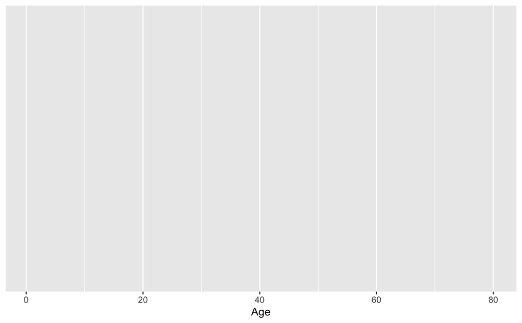

```r
ggplot(titanic, aes(x=Age))
```

Gráfico 1

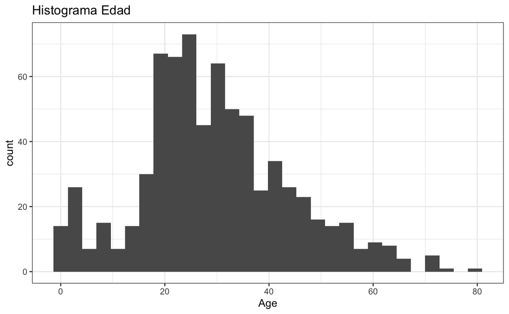

- Gráfico de Densidad (Var. Continuas)

Gráfico 2

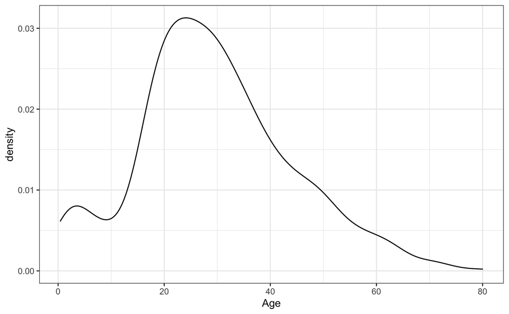

```r
ggplot(titanic, aes(x=Age)) + geom_density()  + theme_bw()
```

- Barras (Var. Discretas)

Gráfico 3

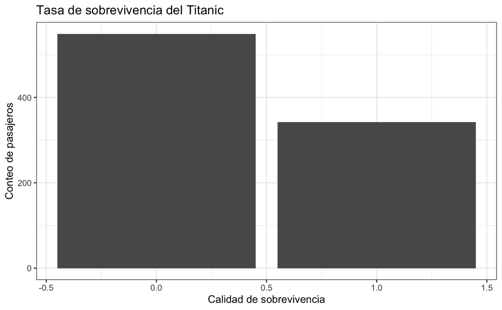

```r
ggplot(titanic,aes(x=Survived)) +
  geom_bar() + theme_bw() +
  labs(y = "Conteo de pasajeros", x= "Calidad de sobrevivencia",
       title = "Tasa de sobrevivencia del Titanic")
```

```r
titanic$Sex<-as.factor(titanic$Sex)
titanic$Pclass<-as.factor(titanic$Pclass)
ggplot(aes(x=Survived), data=titanic) +
  geom_bar() +
   theme_bw() +
    labs(y = "Conteo de pasajeros", x= "Calidad de sobrevivencia",
       title = "Tasa de sobrevivencia del Titanic por sexo") +
         facet_grid(~Sex)
```

[output not shown]

```r
titanic$Survived<-as.factor(titanic$Survived)
ggplot(titanic, aes(x = Pclass, fill = Survived)) +
  geom_bar() +
     theme_bw() +
    labs(y = "Conteo de pasajeros", x= "Calidad de sobrevivencia",
       title = "Tasa de sobrevivencia del Titanic por clase")
```

[output not shown]

##### Primera tarea: Recrear el gráfico 4, con el fondo blanco, título y con nombres en los ejes para la variable Fare, y que las barras se encuentren llenas por el puerto en el que se embarcaron.